# Structural basis of epigenetic protection of mouse lymphoid progenitor cells by Dnmt1

Norimasa Iwanami, Kohei Takeshita, Divine-Fondzenyuy Lawir, Isao Suetake, Shoji Tajima, Katarzyna Sikora, Ines Trancoso, Connor O’Meara, Iliana Siamishi, Thomas Clapes, Eirini Trompouki, Yousuke Takahama, Makoto Furutani-Seiki, Hisato Kondoh, Yasushige Yonezawa, Michael Schorpp and Thomas Boehm

## **Summary**

#### Input data

Input data can be obtained under:

- Figure 1B: “https://owncloud.gwdg.de/index.php/s/lvecKi4NY4DlUTX/download” (zebrafish single CpG values intersected with target intervals from Potok et al. 2013, RData format); “https://owncloud.gwdg.de/index.php/s/vaFsvbCidrST2kO/download” (Potok et al. 2013 intervals lifted over to GRCz10 zebrafish genome, bed format),
- Figure 1C: “https://owncloud.gwdg.de/index.php/s/uqSNUHxH1PIwJZn/download” (medaka amplicon single CpG values extracted for the target intervals from Potok et al. 2013., RData format); “https://owncloud.gwdg.de/index.php/s/IBcLPYo46QiZGzm/download” (Potok et al. 2013 intervals lifted over to MEDAKA1 genome and corrected for primer placement, bed format),
- Figure 7A: “https://owncloud.gwdg.de/index.php/s/rablpH3ijlfw90d/download” (mouse HSC CpG methylation values aggregated over DMRs, RData format),
- Figure 7B: “https://owncloud.gwdg.de/index.php/s/n4oOMZ5Xep6C6Vv/download” (mouse HSC differential gene expression results, tsv format); “https://owncloud.gwdg.de/index.php/s/wEgdccTzvNZTU9b/download” (mouse MPP1 differential gene expression results, tsv format); “https://owncloud.gwdg.de/index.php/s/zXhk3mrbcwyRfuE/download” (mouse MPP4 differential gene expression results, tsv format),
- Figure 7C: “https://owncloud.gwdg.de/index.php/s/sO9gPebqq1jPhcu/download” (mouse HSC de novo DMRs, txt format)

```r
suppressPackageStartupMessages({
    library(data.table, quietly = TRUE)
    library(dplyr, quietly = TRUE)
    library(reshape2, quietly = TRUE)
    library(ggplot2, quietly = TRUE)
    library(magrittr, quietly = TRUE)
    library(limma, quietly = TRUE)
    library(car, quietly = TRUE)
    library(curl, quietly = TRUE)
    library(biomaRt, quietly = TRUE)
    library(gridExtra, quietly = TRUE)
    library(cowplot, quietly = TRUE)
    library(VennDiagram, quietly = TRUE)
    library(Gviz, quietly = TRUE)
    library(GenomicRanges, quietly = TRUE)
    library(RColorBrewer, quietly = TRUE)
    library(biomaRt, quietly = TRUE)
})
```

#### Figure 1B: Methylation ratios per target region in zebrafish.

Methylation status of several genomic regions in zebrafish has been documented by Potok et al. 2013. We ask whether these regions are differentially methylated between dnmt1 wildtype and mutant fish (whole embryo).

Load single CpG methylation values from target intervals:

```r
con <- curl("https://owncloud.gwdg.de/index.php/s/lvecKi4NY4DlUTX/download",
    open = "rb")
load(con)
close(con)

dim(limdat.LG.inCGI)
```

```
## [1] 195   9
```

```r
head(limdat.LG.inCGI)
```

```
##               ms       WT1 WT2 WT3       MT1       MT2       MT3 NAf
## 1: chr10_6925294        NA  NA  NA        NA        NA        NA   1
## 2: chr10_6925296        NA  NA  NA        NA        NA        NA   1
## 3: chr10_6925304 0.5000000  NA  NA        NA        NA        NA   1
## 4: chr10_6925307 0.5000000  NA  NA 0.5000000        NA        NA   1
## 5: chr10_6925317 0.3076923  NA  NA 0.5000000 0.3571429 0.1666667   1
## 6: chr10_6925325 0.4666667  NA  NA 0.4615385 0.3571429 0.2500000   1
##    CGI.ind
## 1:       1
## 2:       1
## 3:       1
## 4:       1
## 5:       1
## 6:       1
```

CpG positions are stored in the “ms” string, “NAf” equals 1 where more than 1 NA was found per row of the methylation matrix (i.e. more than 1 sample had missing values) and “CGI.ind” is the index of the target interval in the bed file.

The number of CpGs with more than 1 missing value in the sample set are counted:

```r
limdat.LG.inCGI$NA.inCGI <- with(limdat.LG.inCGI, ave(NAf, factor(CGI.ind),
    FUN = sum))
head(limdat.LG.inCGI)
```

```
##               ms       WT1 WT2 WT3       MT1       MT2       MT3 NAf
## 1: chr10_6925294        NA  NA  NA        NA        NA        NA   1
## 2: chr10_6925296        NA  NA  NA        NA        NA        NA   1
## 3: chr10_6925304 0.5000000  NA  NA        NA        NA        NA   1
## 4: chr10_6925307 0.5000000  NA  NA 0.5000000        NA        NA   1
## 5: chr10_6925317 0.3076923  NA  NA 0.5000000 0.3571429 0.1666667   1
## 6: chr10_6925325 0.4666667  NA  NA 0.4615385 0.3571429 0.2500000   1
##    CGI.ind NA.inCGI
## 1:       1       17
## 2:       1       17
## 3:       1       17
## 4:       1       17
## 5:       1       17
## 6:       1       17
```

Load the bed file with annotated intervals:

```r
con <- curl("https://owncloud.gwdg.de/index.php/s/vaFsvbCidrST2kO/download",
    open = "r")
CGI.bed <- read.table(con, sep = "\t", header = FALSE, quote = "", as.is = TRUE)
close(con)

dim(CGI.bed)
```

```
## [1] 15  4
```

Annotate bed file with gene symbols from Potok et al.:

```r
colnames(CGI.bed) <- c("CHROM", "START", "END", "Index")
CGI.bed$GeneSymbol <- c("Vasa", "cpn1", "zgc101640", "dnmt6", "Ntla", "dazl",
    "pou5f1", "krt8", "dnmt3", "rarga", "hoxb3a", "hoxb1a", "zgc92231", "krt4",
    "irx3a")
head(CGI.bed)
```

```
##   CHROM    START      END Index GeneSymbol
## 1 chr10  6925257  6925515     1       Vasa
## 2 chr12 31501422 31501726     2       cpn1
## 3 chr16 13534358 13534594     3  zgc101640
## 4 chr17 37041287 37041475     4      dnmt6
## 5 chr19 14329163 14329396     5       Ntla
## 6 chr19 20819052 20819236     6       dazl
```

For each target interval, add information on number of CpGs with missing values and total number of CpGs:

```r
## number of CpGs with missing values
CGI.bed$N.CG.NA <- limdat.LG.inCGI$NA.inCGI[match(CGI.bed$Index, limdat.LG.inCGI$CGI.ind)]

## total number of CpGs per interval
N.CG.tot <- with(limdat.LG.inCGI, ave(NAf, CGI.ind, FUN = length))
CGI.bed$N.CG.tot <- N.CG.tot[match(CGI.bed$Index, limdat.LG.inCGI$CGI.ind)]

head(CGI.bed)
```

```
##   CHROM    START      END Index GeneSymbol N.CG.NA N.CG.tot
## 1 chr10  6925257  6925515     1       Vasa      17       21
## 2 chr12 31501422 31501726     2       cpn1       2        7
## 3 chr16 13534358 13534594     3  zgc101640       0       10
## 4 chr17 37041287 37041475     4      dnmt6       5        6
## 5 chr19 14329163 14329396     5       Ntla      14       18
## 6 chr19 20819052 20819236     6       dazl      11       14
```

Set a filtering vector for intervals with more than 80% of total CpGs having missing values:

```r
CGI.nadat <- ifelse(CGI.bed$N.CG.NA > (0.8 * CGI.bed$N.CG.tot), NA, 1)
CGI.bed$CGI.NAf <- CGI.nadat
CGI.bed.CC <- CGI.bed[complete.cases(CGI.bed), ]
CGI.bed.CC
```

```
##    CHROM    START      END Index GeneSymbol N.CG.NA N.CG.tot CGI.NAf
## 2  chr12 31501422 31501726     2       cpn1       2        7       1
## 3  chr16 13534358 13534594     3  zgc101640       0       10       1
## 5  chr19 14329163 14329396     5       Ntla      14       18       1
## 6  chr19 20819052 20819236     6       dazl      11       14       1
## 7  chr21 13593353 13593608     7     pou5f1      11       18       1
## 8  chr23 10318994 10319162     8       krt8       3        5       1
## 9  chr23 17078533 17079166     9      dnmt3      18       34       1
## 10 chr23 35819872 35820107    10      rarga      11       14       1
## 11  chr3 23579672 23579982    11     hoxb3a       4       11       1
## 13  chr6  8501037  8501416    13   zgc92231       5        9       1
## 14  chr6 39315116 39315339    14       krt4       1        5       1
## 15  chr7 35771563 35771779    15      irx3a       6       11       1
```

To produce data underlying Figure 1B, single CpG methylation values are aggregated per target interval for every sample:

```r
CGI.limdat <- as.data.frame(apply(limdat.LG.inCGI[, 2:7, with = FALSE], 2, function(X) {
    ave(X, factor(limdat.LG.inCGI$CGI.ind), FUN = function(X) mean(X, na.rm = TRUE))
}), stringsAsFactors = FALSE)  ## mean as aggregating function
rownames(CGI.limdat) <- limdat.LG.inCGI$ms

CGI.limdat$CGI.ind <- limdat.LG.inCGI$CGI.ind
CGI.limdat <- unique(CGI.limdat)
CGI.limdat <- CGI.limdat[order(CGI.limdat$CGI.ind), ]
rownames(CGI.limdat) <- CGI.limdat$CGI.ind
CGI.limdat <- CGI.limdat[, -grep("CGI.ind", colnames(CGI.limdat))]
dim(CGI.limdat)
```

```
## [1] 15  6
```

```r
CGI.limdat
```

```
##           WT1       WT2       WT3        MT1        MT2        MT3
## 1  0.55033594 0.3636364 0.5056818 0.27575758 0.29196785 0.29240260
## 2  0.15316742 0.3514012 0.3791100 0.09659091 0.08088340 0.05217803
## 3  0.23112862 0.2402839 0.2542928 0.06743697 0.09129902 0.10573194
## 4         NaN 0.2248618 0.1409091 0.04195804 0.01666667 0.02222222
## 5  0.57179487 0.6178721 0.5548982 0.41536160 0.33808633 0.30481481
## 6  0.80794290 0.8043561 0.8405303 0.69921609 0.48918581 0.59059396
## 7  0.05651515 0.1025715 0.1171329 0.11330414 0.05295482 0.13117789
## 8  0.36363636 0.2262626 0.4070513 0.12442832 0.00000000 0.07207792
## 9  0.62142759 0.6595200 0.5895538 0.22339689 0.26403847 0.13197752
## 10 0.38787879 0.3785603 0.1615385 0.08820319 0.13151154 0.03093829
## 11 0.20400895 0.2691145 0.2526937 0.08813017 0.13252362 0.15758755
## 12 0.05000000 0.2016317 0.1880342 0.05810106 0.06250000 0.32620321
## 13 0.38956229 0.1197279 0.3500891 0.11298701 0.16503867 0.06787879
## 14 0.46032389 0.4821429 0.6461538 0.40945652 0.29033189 0.38853993
## 15 0.15174825 0.1217782 0.1196062 0.08318355 0.07832244 0.02564103
```

Filter out intervals using the filtering vector from above:

```r
CGI.limdat.CC <- CGI.limdat[!is.na(CGI.nadat), ]
dim(CGI.limdat.CC)
```

```
## [1] 12  6
```

Prepare data for plotting:

```r
CGI.limdat.CC$Index <- rownames(CGI.limdat.CC)
plotdat <- melt(CGI.limdat.CC, value.name = "BetaMean", variable.name = "SampleID",
    id.vars = "Index")
head(plotdat)
```

```
##   Index SampleID   BetaMean
## 1     2      WT1 0.15316742
## 2     3      WT1 0.23112862
## 3     5      WT1 0.57179487
## 4     6      WT1 0.80794290
## 5     7      WT1 0.05651515
## 6     8      WT1 0.36363636
```

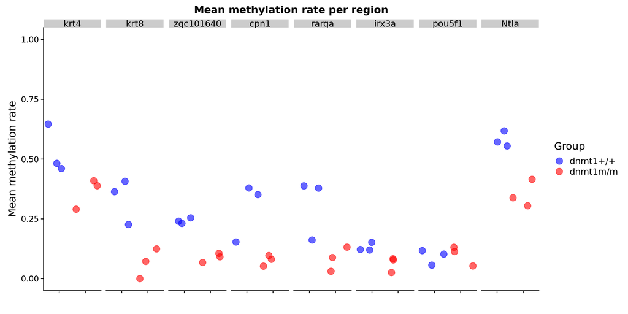

Figure 1B. Interval mean methylation ratio in zebrafish data.

```r
plotdat$GeneSymbol <- CGI.bed$GeneSymbol[match(plotdat$Index, CGI.bed$Index)]
## subset for the 8 gene symbols matching the medaka target intervals
plotdat <- plotdat[plotdat$GeneSymbol %in% c("cpn1", "zgc101640", "Ntla", "krt8",
    "pou5f1", "rarga", "krt4", "irx3a"), ]
plotdat$Group <- NA
plotdat$Group[grep("WT", plotdat$SampleID)] <- "dnmt1+/+"
plotdat$Group[grep("MT", plotdat$SampleID)] <- "dnmt1m/m"
plotdat$Group <- factor(plotdat$Group, levels = c("dnmt1+/+", "dnmt1m/m"))
plotdat$GeneSymbol <- factor(plotdat$GeneSymbol, levels = c("krt4", "krt8",
    "zgc101640", "cpn1", "rarga", "irx3a", "pou5f1", "Ntla"))

ggplot(data = plotdat, aes(x = Group, y = BetaMean)) + geom_point(aes(colour = Group),
    position = position_jitter(width = 0.5, height = 1e-04, seed = 124), size = 4,
    alpha = 0.6) + facet_grid(. ~ GeneSymbol) + ggtitle("Mean methylation rate per region") +
    theme(text = element_text(size = 14), axis.text.y = element_text(size = 11),
        axis.text.x = element_blank(), axis.title = element_text(size = 14)) +
    xlab("") + ylab("Mean methylation rate") + ylim(0, 1) + scale_colour_manual(values = c("blue",
    "red"))
```

Significance testing for differential methylation in the zebrafish dataset:

```r
## logit transform the interval means
plotdat$logit25 <- logit(p = plotdat$BetaMean, percents = FALSE, adjust = 0.025)

GSv <- unique(as.character(plotdat$GeneSymbol))
res <- data.frame(GSv, stringsAsFactors = FALSE)
res$MT <- NA
res$WT <- NA
res$logitMT <- NA
res$logitWT <- NA
res$pval <- NA

for (i in seq_along(GSv)) {
    td <- plotdat[plotdat$GeneSymbol %in% GSv[i], ]

    res$MT[i] <- mean(td$BetaMean[td$Group %in% "dnmt1m/m"])
    res$WT[i] <- mean(td$BetaMean[td$Group %in% "dnmt1+/+"])
    res$logitMT[i] <- mean(td$logit25[td$Group %in% "dnmt1m/m"])
    res$logitWT[i] <- mean(td$logit25[td$Group %in% "dnmt1+/+"])

    z <- t.test(x = td$logit25[td$Group %in% "dnmt1m/m"], y = td$logit25[td$Group %in%
        "dnmt1+/+"], var.equal = TRUE)
    res$pval[i] <- z$p.value

}

res <- res[order(res$pval), ]
res
```

```
##         GSv         MT         WT    logitMT    logitWT        pval
## 2 zgc101640 0.08815598 0.24190179 -2.1133659 -1.0736921 0.000896874
## 3      Ntla 0.35275425 0.58152171 -0.5797091  0.3131809 0.004300794
## 1      cpn1 0.07655078 0.29455954 -2.2396499 -0.8767304 0.023652094
## 5      krt8 0.06550208 0.33231676 -2.5748012 -0.6800570 0.036312900
## 6     rarga 0.08355101 0.30932586 -2.2312853 -0.8098083 0.043347855
## 8     irx3a 0.06238234 0.13104423 -2.4383811 -1.7426375 0.062161598
## 7      krt4 0.36277611 0.52954020 -0.5403319  0.1171402 0.074891043
## 4    pou5f1 0.09914562 0.09207317 -2.0411016 -2.0921183 0.874087075
```

Several of the inspected intervals are differentially methylated (hypomethylated) in dnmt1 mutant zebrafish.

#### Figure 1C: Methylation ratios per target region in medaka.

We ask whether methylation status of homologous genomic intervals is affected in medaka dnmt1 mutants.  
The same procedure is applied as for zebrafish data. Objects are overwritten.

Load single CpG methylation values from target intervals:

```r
con <- curl("https://owncloud.gwdg.de/index.php/s/uqSNUHxH1PIwJZn/download",
    open = "rb")
load(con)
close(con)

dim(limdat.LG.inCGI)
```

```
## [1] 77  9
```

```r
head(limdat.LG.inCGI)
```

```
##                ms        Mut1        Mut2        Mut3         WT1
## 1: chr11_26717902 0.004013042 0.003509212 0.005014416 0.005013788
## 2: chr11_26717905 0.002765209 0.003139915 0.004147292 0.004775669
## 3: chr11_26717925 0.002878959 0.002881844 0.001878522 0.004257984
## 4: chr11_26717929 0.002763472 0.004396985 0.004143126 0.005406085
## 5: chr11_26717936 0.002631249 0.002632569 0.002004510 0.004638917
## 6: chr11_26717946 0.003018868 0.003901334 0.003649176 0.006286936
##            WT2         WT3 NAf CGI.ind
## 1: 0.004260652 0.003885199   0       1
## 2: 0.001884896 0.005397941   0       1
## 3: 0.003756104 0.003753754   0       1
## 4: 0.004779273 0.004268140   0       1
## 5: 0.004764293 0.005137845   0       1
## 6: 0.005789076 0.005157233   0       1
```

CpG positions are stored in the “ms” string, “NAf” equals 1 where more than 1 NA was found per row of the methylation matrix (i.e. more than 1 sample had missing values) and “CGI.ind” is the index of the target interval in the bed file.

The number of CpGs with more than 1 missing value in the sample set are counted:

```r
limdat.LG.inCGI$NA.inCGI <- with(limdat.LG.inCGI, ave(NAf, factor(CGI.ind),
    FUN = sum))
head(limdat.LG.inCGI)
```

```
##                ms        Mut1        Mut2        Mut3         WT1
## 1: chr11_26717902 0.004013042 0.003509212 0.005014416 0.005013788
## 2: chr11_26717905 0.002765209 0.003139915 0.004147292 0.004775669
## 3: chr11_26717925 0.002878959 0.002881844 0.001878522 0.004257984
## 4: chr11_26717929 0.002763472 0.004396985 0.004143126 0.005406085
## 5: chr11_26717936 0.002631249 0.002632569 0.002004510 0.004638917
## 6: chr11_26717946 0.003018868 0.003901334 0.003649176 0.006286936
##            WT2         WT3 NAf CGI.ind NA.inCGI
## 1: 0.004260652 0.003885199   0       1        0
## 2: 0.001884896 0.005397941   0       1        0
## 3: 0.003756104 0.003753754   0       1        0
## 4: 0.004779273 0.004268140   0       1        0
## 5: 0.004764293 0.005137845   0       1        0
## 6: 0.005789076 0.005157233   0       1        0
```

Load the bed file with annotated intervals:

```r
con <- curl("https://owncloud.gwdg.de/index.php/s/IBcLPYo46QiZGzm/download",
    open = "r")
CGI.bed <- read.table(con, sep = "\t", header = FALSE, quote = "", as.is = TRUE)
close(con)

dim(CGI.bed)
```

```
## [1] 8 4
```

Annotate bed file with gene symbols from Potok et al.:

```r
colnames(CGI.bed) <- c("CHROM", "START", "END", "Index")
CGI.bed$GeneSymbol <- c("Ntla", "pou5f1", "zgc101640", "cpn1", "irx3a", "krt4",
    "krt8", "rarga")
```

For each target interval, add information on number of CpGs with missing values and total number of CpGs:

```r
## number of CpGs with missing values
CGI.bed$N.CG.NA <- limdat.LG.inCGI$NA.inCGI[match(CGI.bed$Index, limdat.LG.inCGI$CGI.ind)]

## total number of CpGs per interval
N.CG.tot <- with(limdat.LG.inCGI, ave(NAf, CGI.ind, FUN = length))
CGI.bed$N.CG.tot <- N.CG.tot[match(CGI.bed$Index, limdat.LG.inCGI$CGI.ind)]
```

Set a filtering vector for intervals with more than 80% of total CpGs having missing values:

```r
CGI.nadat <- ifelse(CGI.bed$N.CG.NA > (0.8 * CGI.bed$N.CG.tot), NA, 1)
CGI.bed$CGI.NAf <- CGI.nadat
CGI.bed.CC <- CGI.bed[complete.cases(CGI.bed), ]
## CGI.bed
CGI.bed.CC
```

```
##   CHROM    START      END Index GeneSymbol N.CG.NA N.CG.tot CGI.NAf
## 1 chr11 26717868 26718032     1       Ntla       0       17       1
## 2 chr12 15548739 15548917     2     pou5f1       0       16       1
## 3 chr16 16556614 16556836     3  zgc101640       0        5       1
## 4 chr19  4328008  4328196     4       cpn1       0       11       1
## 5  chr3 28408884 28409081     5      irx3a       0       13       1
## 6  chr5 30362215 30362422     6       krt4       0        4       1
## 7  chr7  3315140  3315349     7       krt8       0        4       1
## 8  chr7 12754429 12754645     8      rarga       0        7       1
```

In the medaka dataset, the high coverage from aplicon sequencing allows for retaining all considered intervals. To produce data underlying Figure 1C, single CpG methylation values are aggregated per target interval for every sample:

```r
CGI.limdat <- as.data.frame(apply(limdat.LG.inCGI[, 2:7, with = FALSE], 2, function(X) {
    ave(X, factor(limdat.LG.inCGI$CGI.ind), FUN = function(X) mean(X, na.rm = TRUE))
}), stringsAsFactors = FALSE)  ## mean as aggregating function
rownames(CGI.limdat) <- limdat.LG.inCGI$ms

CGI.limdat$CGI.ind <- limdat.LG.inCGI$CGI.ind
CGI.limdat <- unique(CGI.limdat)
CGI.limdat <- CGI.limdat[order(CGI.limdat$CGI.ind), ]
rownames(CGI.limdat) <- CGI.limdat$CGI.ind
CGI.limdat <- CGI.limdat[, -grep("CGI.ind", colnames(CGI.limdat))]
CGI.limdat
```

```
##          Mut1        Mut2        Mut3         WT1         WT2         WT3
## 1 0.003247428 0.004504224 0.002376027 0.005747851 0.004438256 0.004924357
## 2 0.026378699 0.020248666 0.021135291 0.059028267 0.054368540 0.058313370
## 3 0.071026041 0.076203138 0.080851217 0.183178749 0.175901394 0.176856934
## 4 0.119234798 0.139656322 0.126104852 0.428170162 0.372835583 0.406641682
## 5 0.056656002 0.064069910 0.055565195 0.098555489 0.092399084 0.084960822
## 6 0.344363610 0.378413857 0.355558420 0.592080602 0.578761754 0.578549422
## 7 0.097738094 0.103538127 0.095896820 0.223525487 0.207336312 0.225746906
## 8 0.015947977 0.018958026 0.021503607 0.074407327 0.068926183 0.067236869
```

Filter out intervals using the filtering vector from above:

```r
CGI.limdat.CC <- CGI.limdat[!is.na(CGI.nadat), ]
```

Prepare data for plotting:

```r
CGI.limdat.CC$Index <- rownames(CGI.limdat.CC)
plotdat <- melt(CGI.limdat.CC, value.name = "BetaMean", variable.name = "SampleID",
    id.vars = "Index")
head(plotdat)
```

```
##   Index SampleID    BetaMean
## 1     1     Mut1 0.003247428
## 2     2     Mut1 0.026378699
## 3     3     Mut1 0.071026041
## 4     4     Mut1 0.119234798
## 5     5     Mut1 0.056656002
## 6     6     Mut1 0.344363610
```

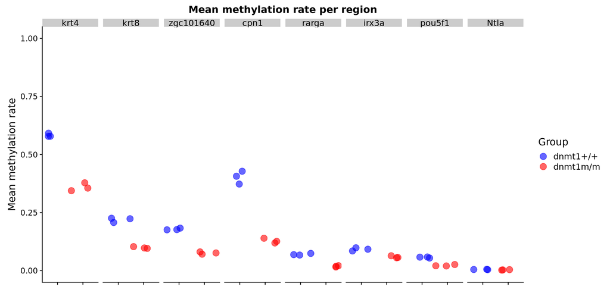

Figure 1C. Interval mean methylation ratio in medaka data.

```r
plotdat$GeneSymbol <- CGI.bed$GeneSymbol[match(plotdat$Index, CGI.bed$Index)]
## subset for the 8 gene symbols matching the medaka target intervals
plotdat <- plotdat[plotdat$GeneSymbol %in% c("cpn1", "zgc101640", "Ntla", "krt8",
    "pou5f1", "rarga", "krt4", "irx3a"), ]
plotdat$Group <- NA
plotdat$Group[grep("WT", plotdat$SampleID)] <- "dnmt1+/+"
plotdat$Group[grep("Mut", plotdat$SampleID)] <- "dnmt1m/m"
plotdat$Group <- factor(plotdat$Group, levels = c("dnmt1+/+", "dnmt1m/m"))
plotdat$GeneSymbol <- factor(plotdat$GeneSymbol, levels = c("krt4", "krt8",
    "zgc101640", "cpn1", "rarga", "irx3a", "pou5f1", "Ntla"))

ggplot(data = plotdat, aes(x = Group, y = BetaMean)) + geom_point(aes(colour = Group),
    position = position_jitter(width = 0.5, height = 1e-04, seed = 123), size = 4,
    alpha = 0.6) + facet_grid(. ~ GeneSymbol) + ggtitle("Mean methylation rate per region") +
    theme(text = element_text(size = 14), axis.text.y = element_text(size = 11),
        axis.text.x = element_blank(), axis.title = element_text(size = 14)) +
    xlab("") + ylab("Mean methylation rate") + ylim(0, 1) + scale_colour_manual(values = c("blue",
    "red"))
```

Significance testing for differential methylation in the medaka dataset:

```r
## logit transform the interval means
plotdat$logit25 <- logit(p = plotdat$BetaMean, percents = FALSE, adjust = 0.025)

GSv <- unique(as.character(plotdat$GeneSymbol))
res <- data.frame(GSv, stringsAsFactors = FALSE)
res$MT <- NA
res$WT <- NA
res$logitMT <- NA
res$logitWT <- NA
res$pval <- NA

for (i in seq_along(GSv)) {
    td <- plotdat[plotdat$GeneSymbol %in% GSv[i], ]

    res$MT[i] <- mean(td$BetaMean[td$Group %in% "dnmt1m/m"])
    res$WT[i] <- mean(td$BetaMean[td$Group %in% "dnmt1+/+"])
    res$logitMT[i] <- mean(td$logit25[td$Group %in% "dnmt1m/m"])
    res$logitWT[i] <- mean(td$logit25[td$Group %in% "dnmt1+/+"])

    z <- t.test(x = td$logit25[td$Group %in% "dnmt1m/m"], y = td$logit25[td$Group %in%
        "dnmt1+/+"], var.equal = TRUE)
    res$pval[i] <- z$p.value

}

res <- res[order(res$pval), ]
res
```

```
##         GSv          MT          WT    logitMT    logitWT         pval
## 3 zgc101640 0.076026799 0.178645692 -2.2292023 -1.4197854 1.785844e-05
## 7      krt8 0.099057680 0.218869568 -2.0012630 -1.1923794 2.697209e-05
## 6      krt4 0.359445296 0.583130593 -0.5478194  0.3186123 4.091627e-05
## 8     rarga 0.018803203 0.070190126 -3.1072071 -2.2937774 5.339151e-05
## 4      cpn1 0.128331991 0.402549142 -1.7604448 -0.3753977 5.903161e-05
## 2    pou5f1 0.022587552 0.057236726 -3.0231237 -2.4511726 2.133732e-04
## 5     irx3a 0.058763703 0.091971798 -2.4321438 -2.0678179 1.955560e-03
## 1      Ntla 0.003375893 0.005036821 -3.5399999 -3.4836615 8.521053e-02
```

Several of the inspected intervals are differentially methylated (hypomethylated) in dnmt1 mutant medaka.

#### Figure 7A: Methylation ratios per target region in mouse HSCs.

Load the mouse HSC DMR methylation matrix containing DMRs filtered for at least 20% CpGs covered with at least 10x and not intersecting SNPs:

```r
con <- curl("https://owncloud.gwdg.de/index.php/s/rablpH3ijlfw90d/download",
    open = "rb")
load(con)
close(con)

dim(CGI.limdat.CC)
```

```
## [1] 107115      7
```

```r
sum(is.na(CGI.limdat.CC))
```

```
## [1] 0
```

```r
head(CGI.limdat.CC)
```

```
##                        Mut1      Mut2      Mut3       WT1       WT2
## 1_3147418_3148098 0.6244444 0.7266667 0.7433333 0.8700000 0.8933333
## 1_3852776_3853066 0.7655556 0.8066667 0.7055556 0.8500000 0.8944444
## 1_3915679_3916133 0.5130000 0.5540000 0.5820000 0.8050000 0.8100000
## 1_3987467_3987614 0.8100000 0.8333333 0.7722222 0.9355556 0.9211111
## 1_4176055_4176388 0.6100000 0.6890000 0.7420000 0.8610000 0.8500000
## 1_4352336_4352718 0.7318182 0.8372727 0.8227273 0.9572727 0.9154545
##                         WT3             IntID
## 1_3147418_3148098 0.8977778 1_3147418_3148098
## 1_3852776_3853066 0.9111111 1_3852776_3853066
## 1_3915679_3916133 0.8500000 1_3915679_3916133
## 1_3987467_3987614 0.9311111 1_3987467_3987614
## 1_4176055_4176388 0.8560000 1_4176055_4176388
## 1_4352336_4352718 0.9390909 1_4352336_4352718
```

The data frame is already filtered such that only intervals with support from all replicates are retained.

We would like to profile distributions of DMR methylation ratios in groups of dnmt1 wildtype and mutant mouse HSC. We compute group mean methylation ratios per DMR interval:

```r
CGI.limdat.CC.Means <- data.frame(rowMeans(CGI.limdat.CC[, grep("Mut", colnames(CGI.limdat.CC))]))
colnames(CGI.limdat.CC.Means) <- "Mut"
CGI.limdat.CC.Means$Wt <- rowMeans(CGI.limdat.CC[, grep("WT", colnames(CGI.limdat.CC))])

rownames(CGI.limdat.CC.Means) <- CGI.limdat.CC$IntID
head(CGI.limdat.CC.Means)
```

```
##                         Mut        Wt
## 1_3147418_3148098 0.6981481 0.8870370
## 1_3852776_3853066 0.7592593 0.8851852
## 1_3915679_3916133 0.5496667 0.8216667
## 1_3987467_3987614 0.8051852 0.9292593
## 1_4176055_4176388 0.6803333 0.8556667
## 1_4352336_4352718 0.7972727 0.9372727
```

Transform data to long table format with reshape2 and generate the violin plot with ggplot2:

```r
CGI.limdat.CC.MeansL <- melt(CGI.limdat.CC.Means, variable.name = "Group", value.name = "Beta.Mean")
```

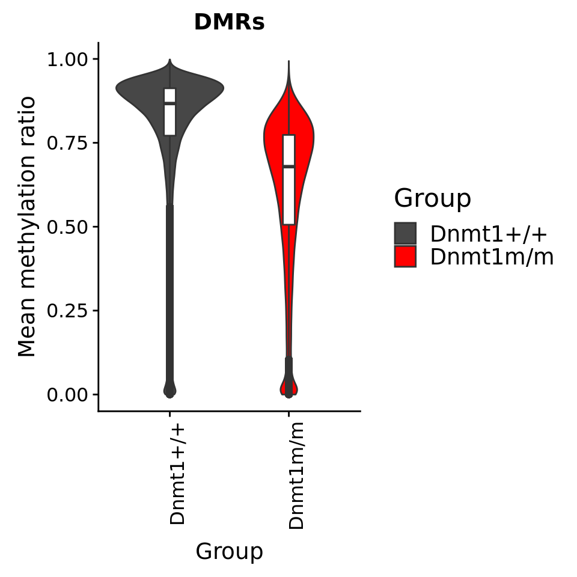

Figure 7A. Violin plot of mean DMR methylation ratio in mouse HSC.

```r
CGI.limdat.CC.MeansL$Group <- as.character(CGI.limdat.CC.MeansL$Group)
CGI.limdat.CC.MeansL$Group[CGI.limdat.CC.MeansL$Group %in% "Mut"] <- "Dnmt1m/m"
CGI.limdat.CC.MeansL$Group[CGI.limdat.CC.MeansL$Group %in% "Wt"] <- "Dnmt1+/+"
CGI.limdat.CC.MeansL$Group <- factor(CGI.limdat.CC.MeansL$Group, levels = c("Dnmt1+/+",
    "Dnmt1m/m"))

ggplot(data = CGI.limdat.CC.MeansL) + geom_violin(aes(x = Group, y = Beta.Mean,
    fill = Group)) + geom_boxplot(aes(x = Group, y = Beta.Mean), width = 0.1) +
    ggtitle("DMRs") + theme(text = element_text(size = 16), axis.text = element_text(size = 12),
    axis.title = element_text(size = 14), axis.text.x = element_text(angle = 90,
        hjust = 1)) + ylab("Mean methylation ratio") + scale_fill_manual(values = c("grey28",
    "red", "darkblue", "darkgreen"))
```

DMRs in Dnmt1 mutant mouse HSCs are partially demethylated.

#### Figure 7B: Log2 fold changes of Fos and Fosb expression in different progenitor populations of Dnmt1 mutant mice.

Load results of differential gene expression from three stem cell and progenitor populations. Select results for genes Fos and Fosb.

```r
cl <- list("https://owncloud.gwdg.de/index.php/s/n4oOMZ5Xep6C6Vv/download",
    "https://owncloud.gwdg.de/index.php/s/wEgdccTzvNZTU9b/download", "https://owncloud.gwdg.de/index.php/s/zXhk3mrbcwyRfuE/download")
names(cl) <- c("HSC", "MPP1", "MPP4")
dfl <- vector("list", 3)
for (i in seq_along(cl)) {
    con <- curl(cl[[i]], open = "r")
    ti <- read.table(con, header = TRUE, sep = "\t", as.is = TRUE, quote = "")
    close(con)
    assign(names(cl)[i], ti)
    print(dim(ti))
    ti$CellPopulation <- names(cl)[i]
    colnames(ti)[1] <- "Gene"
    dfl[[i]] <- ti

}
```

```
## [1] 8 7
## [1] 7 7
## [1] 13  7
```

```r
plotdat <- do.call(rbind, dfl)
plotdat <- subset(plotdat, Gene %in% c("Fos__chr12", "Fosb__chr7"), select = c("Gene",
    "log2FoldChange", "lfcSE", "CellPopulation"))
plotdat$Gene <- gsub("__chr.+", "", plotdat$Gene)
plotdat
```

```
##    Gene log2FoldChange     lfcSE CellPopulation
## 1   Fos       1.578189 0.2752811            HSC
## 7  Fosb       1.534452 0.3193240            HSC
## 9   Fos       2.139593 0.2899464           MPP1
## 13 Fosb       1.618599 0.3005009           MPP1
## 16  Fos       1.892535 0.2677862           MPP4
## 22 Fosb       1.887060 0.3959339           MPP4
```

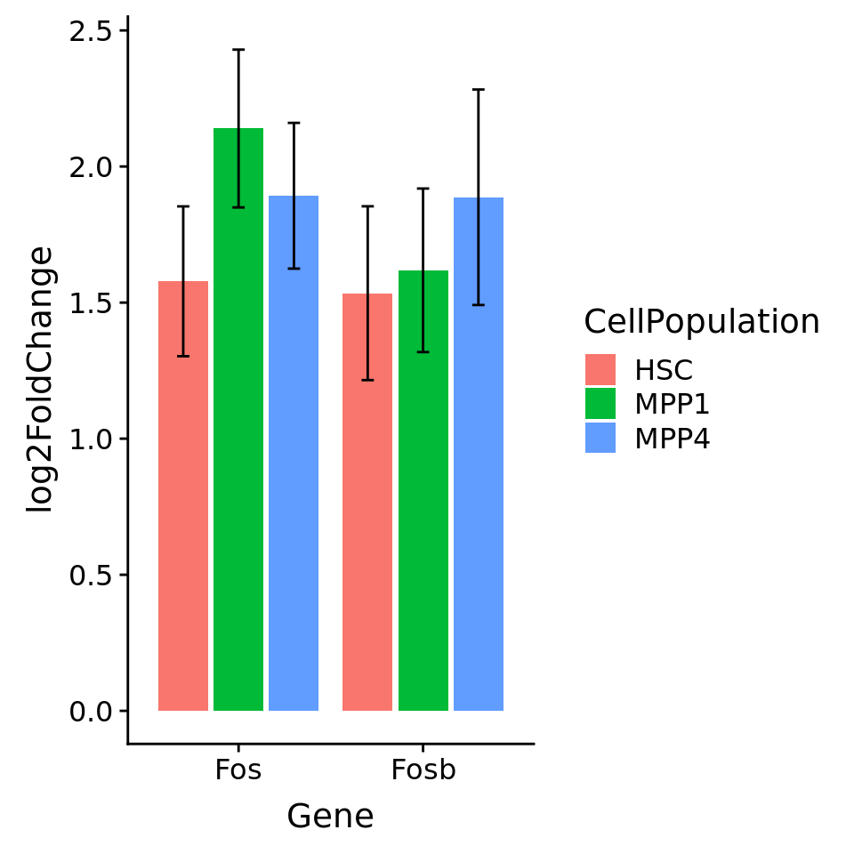

Figure 7B. Fold change in Fos and FosB gene expression in Dnmt1m/m progenitor cells.

```r
plotdat$Gene <- factor(plotdat$Gene, levels = c("Fos", "Fosb"))
plotdat$CellPopulation <- factor(plotdat$CellPopulation, levels = c("HSC", "MPP1",
    "MPP4"))
ggplot(plotdat) + geom_bar(aes(x = Gene, group = CellPopulation, y = log2FoldChange,
    fill = CellPopulation), stat = "identity", position = "dodge2") + geom_errorbar(aes(x = Gene,
    group = CellPopulation, ymin = log2FoldChange - lfcSE, ymax = log2FoldChange +
        lfcSE), width = 0.2, position = position_dodge(width = 0.9))
```

#### Figure 7C: Methylation changes in Fos and Fosb DMRs in Dnmt1m/m mouse HSC.

Load results of differentially methylated region analysis for mouse HSC. Select results for genes Fos and Fosb.

```r
con <- curl("https://owncloud.gwdg.de/index.php/s/sO9gPebqq1jPhcu/download",
    open = "r")
HSC.DMRs <- read.table(con, header = TRUE, sep = "\t", as.is = TRUE, quote = "")
close(con)
HSC.DMRs$IntID <- with(HSC.DMRs, paste0(Chromosome, "_", Start, "_", End))

plotdat <- subset(HSC.DMRs, GeneSymbol %in% c("Fos", "Fosb"), select = c("GeneSymbol",
    "IntID", "MeanA", "MeanB"))
colnames(plotdat)[3:4] <- c("Mut", "Wt")

plotdat
```

```
##       GeneSymbol                IntID     Mut      Wt
## 7476         Fos 12_85425796_85426438 0.48569 0.69725
## 7477         Fos 12_85437243_85437543 0.25033 0.74300
## 7478         Fos 12_85451711_85452456 0.46963 0.69148
## 7479         Fos 12_85453270_85454484 0.61783 0.85971
## 7480         Fos 12_85493609_85494205 0.63933 0.86167
## 7481         Fos 12_85524790_85525319 0.49333 0.79067
## 30507       Fosb  7_19301623_19302563 0.14897 0.42308
## 30508       Fosb  7_19303414_19303893 0.23233 0.45767
## 30509       Fosb  7_19305360_19306061 0.20867 0.53167
## 30510       Fosb  7_19306943_19307670 0.65833 0.88333
```

Reshape and plot data:

```r
plotdatl <- reshape2::melt(plotdat, id.vars = c("GeneSymbol", "IntID"), value.name = "MethylationRatio",
    variable.name = "Genotype")
plotdatl$Genotype <- as.character(plotdatl$Genotype)
plotdatl$Genotype[plotdatl$Genotype %in% "Wt"] <- "Dnmt1+/+"
plotdatl$Genotype[plotdatl$Genotype %in% "Mut"] <- "Dnmt1m/m"
head(plotdatl)
```

```
##   GeneSymbol                IntID Genotype MethylationRatio
## 1        Fos 12_85425796_85426438 Dnmt1m/m          0.48569
## 2        Fos 12_85437243_85437543 Dnmt1m/m          0.25033
## 3        Fos 12_85451711_85452456 Dnmt1m/m          0.46963
## 4        Fos 12_85453270_85454484 Dnmt1m/m          0.61783
## 5        Fos 12_85493609_85494205 Dnmt1m/m          0.63933
## 6        Fos 12_85524790_85525319 Dnmt1m/m          0.49333
```

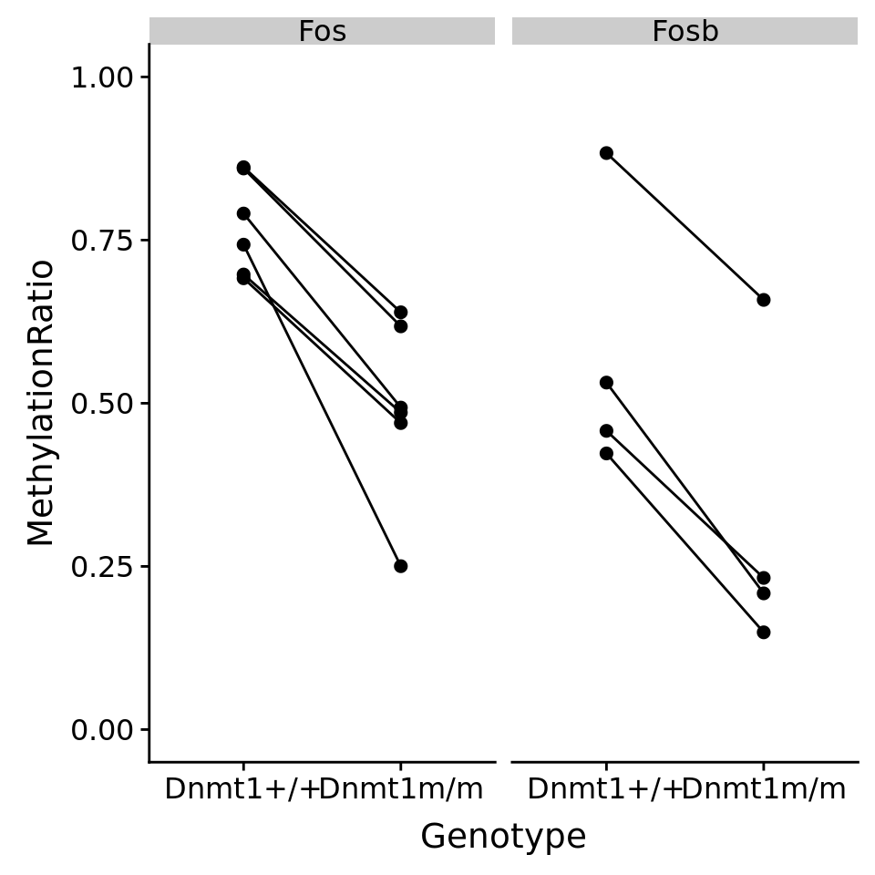

Figure 7C. Fos and Fosb DMR methylation status in Dnmt1 wildtype and mutant mouse HSC.

```r
plotdatl$Genotype <- factor(plotdatl$Genotype, levels = c("Dnmt1+/+", "Dnmt1m/m"))
plotdatl$GeneSymbol <- factor(plotdatl$GeneSymbol, levels = c("Fos", "Fosb"))

ggplot(plotdatl) + geom_line(aes(x = Genotype, y = MethylationRatio, group = IntID)) +
    geom_point(aes(x = Genotype, y = MethylationRatio), size = 2) + ylim(0,
    1) + facet_wrap(~GeneSymbol)
```